# Lab 7

Author

Scott Brydon

```r
library(tidyverse)
library(here)
BlackfootFish <- read_csv(here("data", "BlackfootFish.csv"))
```

#### Task 1

```r
Count_NAs <- function(data) {
  sum(is.na(data))
}

BlackfootFish |>
  summarize(across(.cols = everything(),
         .fns = Count_NAs))
```

```
# A tibble: 1 × 7
   trip  mark length weight  year section species
  <int> <int>  <int>  <int> <int>   <int>   <int>
1     0     0      0   1796     0       0       0
```

#### Task 2

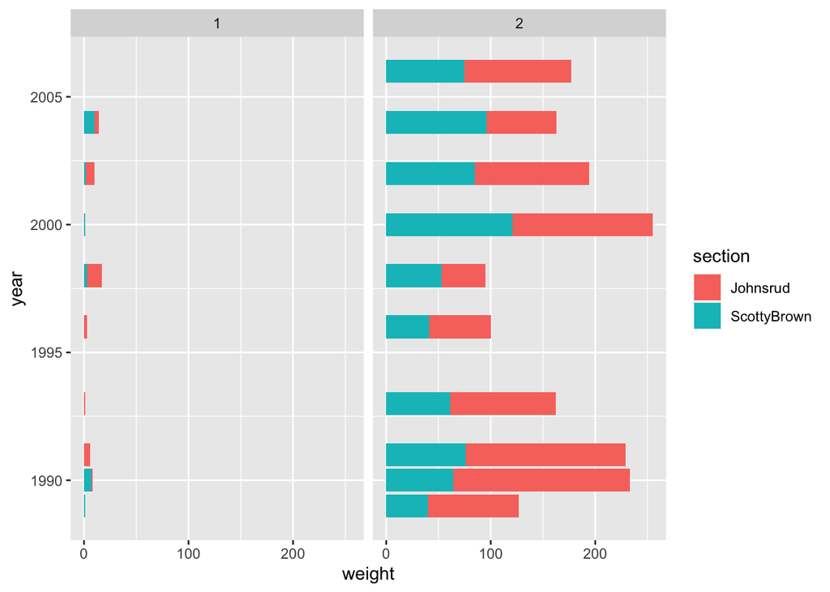

```r
BlackfootFish |>
  group_by(year, trip, section) |>
  summarize(across(.cols = everything(),
         .fns = Count_NAs)) |>
  ggplot(mapping = aes(x = year, y = weight, fill = section)) +
  geom_col() +
  coord_flip() +
  facet_wrap(~ trip)
```

## Part 2:

#### Task 1/2/3

```r
rescale_01 <- function(vector){
  stopifnot(is.numeric(vector), length(vector) > 1)

  min_vec <- min(vector, na.rm = TRUE)
  max_vec <- max(vector, na.rm = TRUE)
  vector <-  (vector - min_vec) / (max_vec - min_vec)

  return(vector)

}

x <- c(1:25, NA)
rescale_01(x)
```

```
 [1] 0.00000000 0.04166667 0.08333333 0.12500000 0.16666667 0.20833333
 [7] 0.25000000 0.29166667 0.33333333 0.37500000 0.41666667 0.45833333
[13] 0.50000000 0.54166667 0.58333333 0.62500000 0.66666667 0.70833333
[19] 0.75000000 0.79166667 0.83333333 0.87500000 0.91666667 0.95833333
[25] 1.00000000         NA
```

#### Task 4

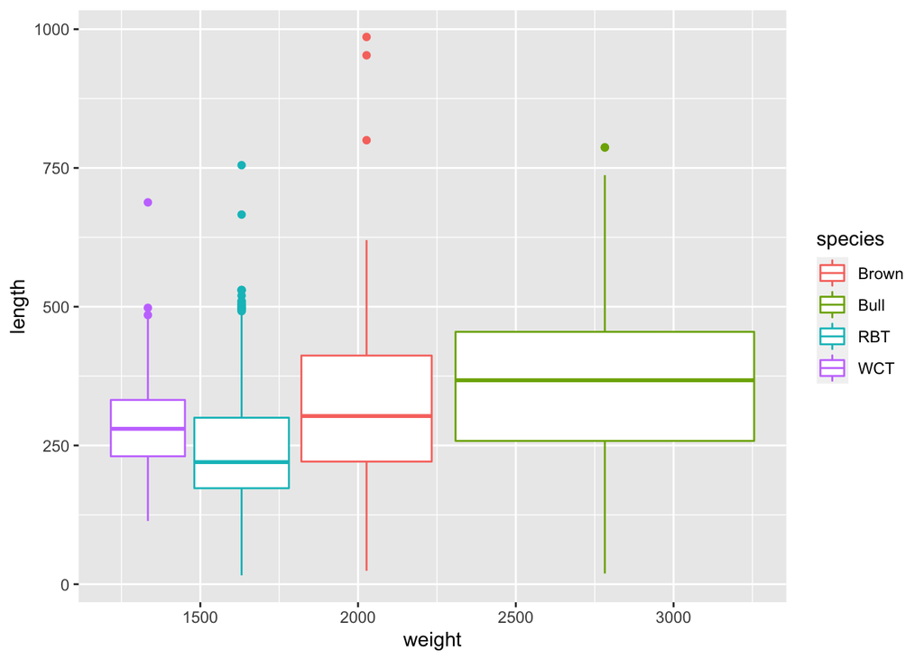

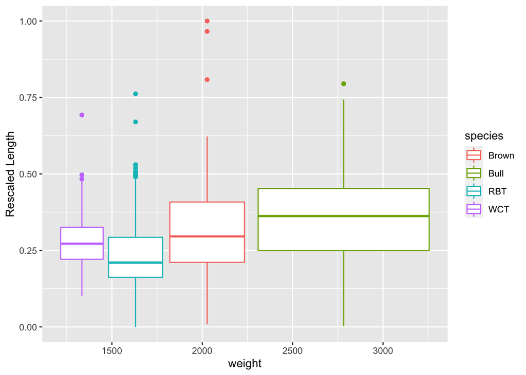

```r
BlackfootFish |>
  ggplot(mapping = aes(
    x = weight,
    y = length,
    color = species)
    ) +
  geom_boxplot()
BlackfootFish |>
  ggplot(mapping = aes(
    x = weight,
    y = rescale_01(length),
    color = species
    )) +
  geom_boxplot() +
  labs(y = "Rescaled Length")
```

#### Task 5/6

```r
rescale_column <- function(data, vectors) {
  stopifnot(is.data.frame(data))

  data %>%
    mutate(
      across(
      .cols = {{ vectors }},
      .fns = rescale_01
      )
    )
}

rescale_column(BlackfootFish, length:weight)
```

```
# A tibble: 18,352 × 7
    trip  mark length  weight  year section  species
   <dbl> <dbl>  <dbl>   <dbl> <dbl> <chr>    <chr>
 1     1     0  0.280 0.0374   1989 Johnsrud RBT
 2     1     0  0.280 0.0406   1989 Johnsrud RBT
 3     1     0  0.277 0.0524   1989 Johnsrud RBT
 4     1     0  0.315 0.0588   1989 Johnsrud RBT
 5     1     0  0.305 0.0641   1989 Johnsrud RBT
 6     1     0  0.358 0.0812   1989 Johnsrud RBT
 7     1     0  0.261 0.0363   1989 Johnsrud RBT
 8     1     0  0.148 0.00855  1989 Johnsrud RBT
 9     1     0  0.203 0.0171   1989 Johnsrud RBT
10     1     0  0.145 0.00748  1989 Johnsrud RBT
# … with 18,342 more rows
```

**Lab 7 Revisions**

**Task 2:** When I had originally formatted the ggplot for the number of NAs in the weight column, I was struggling with the correct plot to use because I had been considering the year as a purely numerical variable in this case, and there tried using geom_line and geom_point. Once I realized that year was acting more as a categorical variable because there would never be any value at a fraction of a year, I reverted to using a bar plot. Once I got to this point, I tried switching the year to the y-axis in the aesthetics argument, but it didn’t produce the horizontal bar graph desired. I assumed this was the best that could be done using ggplot because I hadn’t remembered the usefulness of the coord_flip function. Until you hinted at the possibility of years being on the y-axis in my corrections, I never would have realized I could have flipped it.

**Task 1/2/3:** For the stopifnot function, I didn’t understand the argument structure for the function. I assumed it was a function that reduced the need to write convoluted if statement. Therefore, I figured it would follow the same logical operator structure and require an or symbol between the arguments being tested.

The redundancy in the rescale function was a result of me assuming that since the minimum function is already defined, that I couldn’t replace it with a simpler argument. I had been using the thought process of developing functions to minimize redundancy and knew I couldn’t make another minimize function. This now seems obvious, but I hadn’t thought at the time to just define the minimum and maximum as objects precalculated in the function. This happens a lot to me in this class, where I’ll get so homed in on a specific learning target or way of doing things that I’ll overcomplicated my thinking.